# Modelo de evaluación crediticia

## Modelos de machine learning

### Modelo de regresion logistica

Con este modelo se busca que la interacción de las variables explicativas genere una probabilidad de que la trasacción sea mala.Pasado el umbral del 0.5, se determina que la transacción sería mala. Este modelo podría se alimentado al motor de evaluación en línea para aprobar o declinar las transacciones.

```python
df.info()
```

```
<class 'pandas.core.frame.DataFrame'>
RangeIndex: 824 entries, 0 to 823
Data columns (total 12 columns):
 #   Column            Non-Null Count  Dtype
---  ------            --------------  -----
 0   score_1           824 non-null    object
 1   riesgo_score1     824 non-null    int64
 2   score_2           824 non-null    object
 3   riesgo_score2     824 non-null    int64
 4   interaccion_1     824 non-null    int64
 5   interaccion_2     824 non-null    int64
 6   magnitud_riesgo   824 non-null    int64
 7   monto             824 non-null    int64
 8   mala_transaccion  824 non-null    int64
 9   state             823 non-null    object
 10  poblacion         824 non-null    int64
 11  sc_control        824 non-null    int64
dtypes: int64(9), object(3)
memory usage: 77.4+ KB
```

#### Primera especificación

```python
# Separamos a las variables dependientes de las independientes
X = df[['riesgo_score1', 'riesgo_score2', 'interaccion_1', 'interaccion_2', 'magnitud_riesgo', 'monto', 'poblacion', 'sc_control']]
y = df['mala_transaccion']

# Añadiendo el intercepto
X = sm.add_constant(X)
```

```python
# Instanciando el modelo
logreg1= sm.Logit(y, X)

# Haciendo fit
logreg1_results = logreg1.fit()

# Publicando los resultados
logreg1_results.summary()
```

```
Optimization terminated successfully.
         Current function value: 0.430799
         Iterations 6
```

Logit Regression Results

| Dep. Variable: | mala_transaccion | No. Observations: | 824 |
| --- | --- | --- | --- |
| Model: | Logit | Df Residuals: | 815 |
| Method: | MLE | Df Model: | 8 |
| Date: | Mon, 20 Sep 2021 | Pseudo R-squ.: | 0.1023 |
| Time: | 21:07:16 | Log-Likelihood: | -354.98 |
| converged: | True | LL-Null: | -395.44 |
| Covariance Type: | nonrobust | LLR p-value: | 3.201e-14 |

|  | coef | std err | z | P>\|z\| | [0.025 | 0.975] |
| --- | --- | --- | --- | --- | --- | --- |
| const | -3.1019 | 0.598 | -5.188 | 0.000 | -4.274 | -1.930 |
| riesgo_score1 | 1.0127 | 0.297 | 3.412 | 0.001 | 0.431 | 1.594 |
| riesgo_score2 | -1.0918 | 0.328 | -3.325 | 0.001 | -1.735 | -0.448 |
| interaccion_1 | 0.7925 | 0.495 | 1.602 | 0.109 | -0.177 | 1.762 |
| interaccion_2 | 0.9833 | 0.258 | 3.811 | 0.000 | 0.478 | 1.489 |
| magnitud_riesgo | 0.1717 | 0.163 | 1.053 | 0.292 | -0.148 | 0.491 |
| monto | 0.0110 | 0.005 | 2.033 | 0.042 | 0.000 | 0.022 |
| poblacion | -0.2707 | 0.198 | -1.369 | 0.171 | -0.658 | 0.117 |
| sc_control | -0.5435 | 0.416 | -1.307 | 0.191 | -1.359 | 0.272 |

La variables `magntinud_riesgo`, `interaccion_1`, `población` o `sc_cointrol` no son estadísticamente significativas, pero si se les elimina se pierde poder explicativo y baja ligeramente la precisión. Por ese motivo, trabajaremos con esta especificación.

```python
# Obteniendo las probabilidades de prediccion y transformandolas en una variable binaria para determinar si sería rechazada
model_predictions_prob = logreg1_results.predict(X)
model_predictions_binary = np.where(model_predictions_prob>0.5,1,0)
```

```python
## ¿A cuántas observaciones se les asignó la probabilidad de 1, dado un umbral de 0.5?
model_predictions_binary.sum()
```

```
46
```

```python
## ¿Cuantas predcciones fueron correctas?
(model_predictions_binary == df['mala_transaccion']).sum()
```

```
671
```

```python
print("La precisión del modelo de regresión logística es:", (671/824)*100, "%")
```

```
La precisión del modelo de regresión logística es: 81.43203883495146 %
```

Es ligeramente superior en décimas al término de interacción 1. Pasaremos a calcular la matriz de confusión.

```python
## creando una variable de las predicciones binarias del modelo
pred_bin=model_predictions_binary
```

```python
## insertando esa variable en el dataframe con el nombre pred_bin
df.loc[:,'pred_log']=pred_bin
```

```python
## comprobando que están ambas variables
df.info()
```

```
<class 'pandas.core.frame.DataFrame'>
RangeIndex: 824 entries, 0 to 823
Data columns (total 13 columns):
 #   Column            Non-Null Count  Dtype
---  ------            --------------  -----
 0   score_1           824 non-null    object
 1   riesgo_score1     824 non-null    int64
 2   score_2           824 non-null    object
 3   riesgo_score2     824 non-null    int64
 4   interaccion_1     824 non-null    int64
 5   interaccion_2     824 non-null    int64
 6   magnitud_riesgo   824 non-null    int64
 7   monto             824 non-null    int64
 8   mala_transaccion  824 non-null    int64
 9   state             823 non-null    object
 10  poblacion         824 non-null    int64
 11  sc_control        824 non-null    int64
 12  pred_log          824 non-null    int32
dtypes: int32(1), int64(9), object(3)
memory usage: 80.6+ KB
```

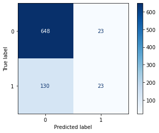

```python
# generando la matriz de confusion
cf_matrix = confusion_matrix(df.mala_transaccion, df.pred_log)

# presentando la matriz
ConfusionMatrixDisplay(cf_matrix).plot(cmap='Blues')
plt.show()
```

```python
## Centremonos solo sobre los falsos negativos
df_zoom2=df[(df.mala_transaccion==1) & (df.pred_log==0)]
```

```python
df_zoom2.shape
```

```
(130, 13)
```

```python
pd.crosstab(df_zoom2.score_1, df_zoom2.score_2)
```

| score_2 score_1 | bueno | excelente | malo | medio |
| --- | --- | --- | --- | --- |
| bueno | 36 | 12 | 7 | 3 |
| excelente | 26 | 10 | 2 | 4 |
| malo | 2 | 0 | 0 | 2 |
| medio | 15 | 2 | 3 | 3 |
| nd | 1 | 1 | 1 | 0 |

Continua el problema de clientes con buenos scores dando transacciones malas.

- score 1, score 2: (bueno, bueno) 36 transacciones malas
- score 1, score 2: (excelente, bueno) 26 transacciones malas
- score 1, score 2: (bueno, excelente) 12 transacciones malas
- score 1, score 2: (excelente, excelente) 10 transacciones malas

Buscaremos de optimizar el nivel de precisión utilizando otros modelos de machine learning no supervisado como el arbol de decisión y el KNN.

### Modelo de arbol de decisión

La principal limitación que tenemos para el uso de modelos de machine learning no supervisado es el numero de observaciones. No va a ser útil separar la separacion de la data en conjuntos de entrenamiento, validación y testeo. Tampoco va a ser posible hacer optimización de hiperparámetros. Aun con esas limitaciones, aplicaremos los modelos al conjunto completo para darnos una idea aproximada a las mejoras que podrían generar.

```python
## Importando la librería
from sklearn.tree import DecisionTreeClassifier
```

```python
## Haciendo fit al modelo con una máxima profundidad de 8 nodos
## Se puede optimizar el número de nodos de manera sistémica. En este caso, por el número de observaciones lo he hecho manual
dt_model = DecisionTreeClassifier(max_depth=8)
dt_model.fit(X,y)

# Score on train and test
print(f"La precision del modelo de arbol de decision es {dt_model.score(X, y)}")
```

```
La precision del modelo de arbol de decision es 0.8543689320388349
```

Mejora ligeramente el modelo, hasta 85.43% de precisión.

```python
# Obteniendo las predicciones del modelo
y_pred_dt = dt_model.predict(X)
```

```python
df.loc[:,'pred_prob_dt']=y_pred_dt
```

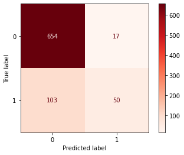

```python
# generando la matriz de confusion
cf_matrix = confusion_matrix(df.mala_transaccion, df.pred_prob_dt)

# presentando la matriz
ConfusionMatrixDisplay(cf_matrix).plot(cmap='Reds')
plt.show()
```

```python
## Centremonos solo sobre los falsos negativos
df_zoom3=df[(df.mala_transaccion==1) & (df.pred_prob_dt==0)]
```

```python
df_zoom3.shape
```

```
(103, 14)
```

```python
pd.crosstab(df_zoom3.score_1, df_zoom3.score_2)
```

| score_2 score_1 | bueno | excelente | malo | medio |
| --- | --- | --- | --- | --- |
| bueno | 23 | 12 | 7 | 2 |
| excelente | 25 | 10 | 2 | 4 |
| malo | 3 | 0 | 0 | 2 |
| medio | 8 | 0 | 0 | 1 |
| nd | 0 | 1 | 1 | 2 |

En comparación al modelo logístico, el modelo de arbol de decisón ha disminuido las malas transacciones que traía la categoría "bueno" del score 2. En el primer caso, eran 80. En este nuevo modelo son 59. En el caso de las malas transacciones que traía la categoría "excelente" del score 2, bajan a 23. Esta mejoras marginales se traducen finalmente en una mayor precisión.

### Modelo de KNN - vecinos cercanos

```python
## Importando la librería
from sklearn.neighbors import KNeighborsClassifier
```

```python
## Haciendo fit al modelo con un número de 10 vecinos
## Se puede optimizar el número de vecinos de manera sistémica. En este caso, por el número de observaciones lo he hecho manual
best_knn= KNeighborsClassifier(n_neighbors=10)
best_knn.fit(X, y)
```

```
KNeighborsClassifier(n_neighbors=10)
```

```python
# Obteniendo las predicciones del modelo
y_pred_knn = best_knn.predict(X)
```

```python
## incluyendo esta prediccion en el df
df.loc[:,'pred_prob_knn']=y_pred_knn
```

```python
print (f"La precision del modelo KNN es {best_knn.score(X,y)}")
```

```
La precision del modelo KNN es 0.8337378640776699
```

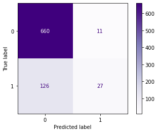

```python
# generando la matriz de confusion
cf_matrix = confusion_matrix(df.mala_transaccion, df.pred_prob_knn)

# presentando la matriz
ConfusionMatrixDisplay(cf_matrix).plot(cmap='Purples')
plt.show()
```

La precisión del modelo KNN es superior al modelo logístico pero inferior al modelo de arbol de decisión.

```python
df.info()
```

```
<class 'pandas.core.frame.DataFrame'>
RangeIndex: 824 entries, 0 to 823
Data columns (total 15 columns):
 #   Column            Non-Null Count  Dtype
---  ------            --------------  -----
 0   score_1           824 non-null    object
 1   riesgo_score1     824 non-null    int64
 2   score_2           824 non-null    object
 3   riesgo_score2     824 non-null    int64
 4   interaccion_1     824 non-null    int64
 5   interaccion_2     824 non-null    int64
 6   magnitud_riesgo   824 non-null    int64
 7   monto             824 non-null    int64
 8   mala_transaccion  824 non-null    int64
 9   state             823 non-null    object
 10  poblacion         824 non-null    int64
 11  sc_control        824 non-null    int64
 12  pred_log          824 non-null    int32
 13  pred_prob_dt      824 non-null    int64
 14  pred_prob_knn     824 non-null    int64
dtypes: int32(1), int64(11), object(3)
memory usage: 93.5+ KB
```

```python
## Exportando la data trabajada hasta el momento
df.to_csv('data_final2_prob.csv', index = False)
```

## Análisis

El uso de modelos de machine learning mejora en 4.4 puntos porcentuales la precisión de la evaluación del riesgo crediticio cuando se les compara con una regla que combina los scores 1 y 2 (85.43% vs 81.06%). Sin embargo, a pesar de esto, la precisión sigue estando por debajo del óptimo. Veamos esto en terminos de dinero, solo utilizando el mejor modelo, el arbol de decisión.

```python
## Quedamos solo con los aciertos del modelo
df_zoom4=df[(df.mala_transaccion==0) & (df.pred_prob_dt==0) | (df.mala_transaccion==1) & (df.pred_prob_dt==1)]
```

```python
## comprobando la forma de la matriz
df_zoom4.shape
```

```
(704, 15)
```

```python
df_zoom4.monto.sum()
```

```
52436
```

Las transacciones correctamente identificadas suman 52436 dolares.

```python
## Identificando el valor de las falsos negativos en la matriz calculada en la seccion del modelo de arbol de decisión
df_zoom3.shape
```

```
(103, 14)
```

```python
df_zoom3.monto.sum()
```

```
7964
```

Los falsos negativos cuestan a la empresa 7964 dolares, a un promedio de 77.32 dólares por transacción.

```python
## Identificando el valor de las falsos positivos
df_zoom5=df[(df.mala_transaccion==0) & (df.pred_prob_dt==1)]
```

```python
df_zoom5.shape
```

```
(17, 15)
```

```python
df_zoom5.monto.sum()
```

```
1302
```

```python
pd.crosstab(df_zoom5.score_1, df_zoom5.score_2)
```

| score_2 score_1 | bueno | excelente | malo | medio |
| --- | --- | --- | --- | --- |
| bueno | 7 | 0 | 0 | 0 |
| malo | 2 | 0 | 0 | 0 |
| medio | 2 | 1 | 0 | 1 |
| nd | 2 | 0 | 2 | 0 |

Al igual que en el caso de los falsos negativos, el principal problema del clasificador viene por las transacciones de la categoría "bueno" del score 2. ¿Cuáles podrían ser algunas alternativas para mejorar este clasificador?

### Alternativas para mejorar la precisión del clasificador

#### Combinar las predicciones de arboles de decision y KNN

El modelo KNN identifica mejor a los negativos (0) y el modelo de arbol de decision identifica mejor a los positivos. La variable `pred_optima` combina los resultados de ambos para dichas clasificaciones. La labor de etiquetado se hizo en Excel. El archivo resultante es data_final_optima.csv.

```python
df=pd.read_csv('data_final_optim.csv', sep=";")
```

```python
df.info()
```

```
<class 'pandas.core.frame.DataFrame'>
RangeIndex: 824 entries, 0 to 823
Data columns (total 16 columns):
 #   Column            Non-Null Count  Dtype
---  ------            --------------  -----
 0   score_1           824 non-null    object
 1   riesgo_score1     824 non-null    int64
 2   score_2           824 non-null    object
 3   riesgo_score2     824 non-null    int64
 4   interaccion_1     824 non-null    int64
 5   interaccion_2     824 non-null    int64
 6   magnitud_riesgo   824 non-null    int64
 7   monto             824 non-null    int64
 8   mala_transaccion  824 non-null    int64
 9   state             823 non-null    object
 10  poblacion         824 non-null    int64
 11  sc_control        824 non-null    int64
 12  pred_log          824 non-null    int64
 13  pred_prob_dt      824 non-null    int64
 14  pred_prob_knn     824 non-null    int64
 15  pred_optima       824 non-null    int64
dtypes: int64(13), object(3)
memory usage: 103.1+ KB
```

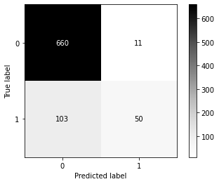

```python
# generando la matriz de confusion
cf_matrix = confusion_matrix(df.mala_transaccion, df.pred_optima)

# presentando la matriz
ConfusionMatrixDisplay(cf_matrix).plot(cmap='Greys')
plt.show()
```

```python
print("La precisión del modelo combinado es:", (710/824)*100, "%")
```

```
La precisión del modelo combinado es: 86.16504854368931 %
```

#### Conseguir una variabe explicativa adicional

Una versión previa del modelo fue trabajada sin las variables `población` y `sc_control`, lográndose una precisión de 84.59% en el modelo de arbol de decisión versus 85.43% en esta versión. Si se incluye alguna otra variable no correlacionada con las anteriores, se podría seguir aumentando la precisión. Por ejemplo, score 2 tiene poca precisión. Se podría pensar en reemplazar esta por otro score, de preferencia uno que tenga una frecuenca de actualización mayor al score 1.

#### Hacer un chequeo telefónico focalizado sobre las principales áreas problemáticas

```python
## Identificando el número falsos negativos en el modelo óptimo hasta el momento
df_zoom6=df[(df.mala_transaccion==1) & (df.pred_optima==0)]
```

```python
df_zoom6.shape
```

```
(103, 16)
```

```python
pd.crosstab(df_zoom6.score_1, df_zoom6.score_2)
```

| score_2 score_1 | bueno | excelente | malo | medio |
| --- | --- | --- | --- | --- |
| bueno | 23 | 12 | 7 | 2 |
| excelente | 25 | 10 | 2 | 4 |
| malo | 3 | 0 | 0 | 2 |
| medio | 8 | 0 | 0 | 1 |
| nd | 0 | 1 | 1 | 2 |

Con cada iteración del modelo, se ha seguido mejorando el proceso de filtrado de las malas transacciones. Sin embargo, las combinaciones de bueno y excelente de ambos scores siguen dando un número alto de transacciones fallidas. ¿Cuánto podría mejorar con un filtrado de llamadas? ¿Caunto es el conjunto universal sobre el que se debería hacer el filtrado?

```python
## El conjunto de malas transacciones con calificación de buena o excelente por alguno de los scores
23+25+12+10
```

```
70
```

```python
print("Esto es el ", (70/103)*100, "% del total de malas transacciones")
```

```
Esto es el  67.96116504854369 % del total de malas transacciones
```

```python
## cuantas transacciones del total corresponde a estas 4 combinaciones de score?
pd.crosstab(df.score_1, df.score_2)
```

| score_2 score_1 | bueno | excelente | malo | medio | nodata |
| --- | --- | --- | --- | --- | --- |
| bueno | 106 | 77 | 19 | 20 | 1 |
| excelente | 227 | 147 | 24 | 74 | 3 |
| malo | 17 | 2 | 1 | 4 | 0 |
| medio | 31 | 17 | 7 | 6 | 0 |
| nd | 14 | 2 | 9 | 15 | 1 |

```python
## El conjunto universal de transacciones por filtar es
106+227+77+147
```

```
557
```

```python
print("Esto es el ", (557/824)*100, "% del total")
```

```
Esto es el  67.59708737864078 % del total
```

Las malas transacciones son proporcionales al número de transacciones totales correspondientes a los categorias 'bueno' o 'excelente' de ambos scores.

Si se hace un muestreo de llamadas:

- 25% de 557 transacciones: 139 llamadas **Con el 100% de respuesta: 25% de 103. 26 transacciones nuevas negadas (negativo, negativo).**

```python
print("La precisión del modelo total sería:", ((710+26)/824)*100, "%")
```

```
La precisión del modelo total sería: 89.32038834951457 %
```

```python
print("La precisión del modelo total sería:", ((710+36)/824)*100, "%")
```

```
La precisión del modelo total sería: 90.53398058252428 %
```

La efectividad final del modelo dependería de si se logra el 100% de respuesta de los bancos. Si esto no es posible, bajará respecto al estimado pues por defecto el motor debería aprobar la operación.

## Conclusiones

Este análisis muestra cómo mejorar la precisón de un sistema de análisis de riesgo tomando como base un score de un proveedor independiente, el score 1. La máxima precisión se logra con una combinacion de modelos de árboles de decisión de 8 nodos y un modelo de 10 vecinos cercanos. Entre las alternativas para mejorar este modelo de clasificación están: